# Formation OpenClassRooms - Parcours DATA ANALYST

## Projet IV - Analysez les ventes de votre entreprise

Mise en situation  
Vous êtes Data Analyst d'une grande chaîne de librairie, fraîchement embauché depuis une semaine !  
Le service informatique vous a donné l’accès à la base de données des ventes. A vous de vous familiariser avec les données, et de les analyser. Votre manager souhaite que vous réalisiez une présentation pour vous "faire la main".

### Mission 2 - Analyse & Graphes

- **Etude Dataframe Clients**
  - Répartition des Ages par client (Fig.M2.1)
  - Age des Clients par Tranches (Fig.M2.2)
  - Répartition des Clients par Sexe (Fig.M2.3)
  - Les 10 plus gros Clients en terme de CA (Fig.M2.4)
- **Etude Dataframe Produits**
  - Distribution des Tarifs Produits par Catégorie (Fig.M2.5) / Skewness (M25bis)
  - Les 10 Produits les plus vendus toutes catégories confondues (Fig.M2.6)
  - Les 10 Produits dont le CA(€) est le plus fort (Fig.M2.6bis)
- **Etude des Transactions**
  - Superposition des analyses suivantes (Fig.M2.7):
    - Evolution des Ventes Annuelles (courbe/fonction y=f(x)
    - Nombre de Ventes par Catégorie par Mois (Barchart multiple)
  - Distribution des CA mensuels sur 1an par catégorie de produits (Fig.M2.8)
  - Nombre de Ventes de chaque catégorie par Tranches Horaires (Fig.M2.9)
- **Courbe de Lorenz / Indice de Gini**
  - Distribution des Ventes (%) **VS** (%) Ventes Cumulées sur 1 an (Fig.M2.10)

**- Date : 31 Jan 2019**  
Auteur : Frédéric Boissy

##### ENVIRONNEMENT DE TRAVAIL : Définition - Initialisation

```python
# -*- coding: utf8 -*-
import numpy as np
import pandas as pd
pd.options.display.float_format = '{:,.2f}'.format   # Nombres avec sepa milliers "," et 2décimales après "."
pd.options.mode.use_inf_as_na = True

import seaborn as sns
import matplotlib as matplt
import matplotlib.pyplot as plt
from matplotlib import patches

import scipy as sc
import scipy.stats as st
import statsmodels as sm

from IPython.display import display, Markdown, HTML  # pour gérer un affichage plus joli que la fonction "print"

import time   # Librairie temps pour calculs durée par exemple
trt_start_time = time.time()
```

```python
# Pour executer des requetes SQL de verification sur des DF
from pandasql import sqldf
execsql = lambda q: sqldf(q, globals())
# req1 = ''' Select zone1, zone2 From DataFrame Where zone3=xx and zone4='xx' limit 3;'''
# df1 = execsql(req1)
# df1
```

##### REPERTOIRE DE TRAVAIL : (du Projet)

Par defaut on utilisera celui dans lequel se trouve ce fichier jupyter

```python
%cd OUTFILES
```

```
D:\DATA_ANALYST\WORK\#GITHUB\PJ4\OUTFILES
```

##### CHARGEMENT DATA "csv" : après nettoyage des donnés dans un Dataframe enrichi

```python
sal = pd.read_csv("m2_sales_avec_outliers_sans_imput_ref.zip")
sal_ref = pd.read_csv("m2_sales_avec_outliers_avec_imput_ref.zip")
cst = pd.read_csv("cst.csv")
prd = pd.read_csv("prd.csv")
sal.info()
sal_ref.info()
```

```
<class 'pandas.core.frame.DataFrame'>
RangeIndex: 336713 entries, 0 to 336712
Data columns (total 14 columns):
session_id      336713 non-null object
client          336713 non-null object
sex             336713 non-null object
age             336713 non-null int64
birthyear       336713 non-null int64
prod            336713 non-null object
price           336713 non-null float64
categ           336713 non-null int64
period          336713 non-null object
year            336713 non-null int64
month           336713 non-null int64
day             336713 non-null int64
time            336713 non-null object
session_date    336713 non-null object
dtypes: float64(1), int64(6), object(7)
memory usage: 36.0+ MB
<class 'pandas.core.frame.DataFrame'>
RangeIndex: 336816 entries, 0 to 336815
Data columns (total 14 columns):
session_id      336816 non-null object
client          336816 non-null object
sex             336816 non-null object
age             336816 non-null int64
birthyear       336816 non-null int64
prod            336816 non-null object
price           336816 non-null float64
categ           336816 non-null int64
period          336816 non-null object
year            336816 non-null int64
month           336816 non-null int64
day             336816 non-null int64
time            336816 non-null object
session_date    336816 non-null object
dtypes: float64(1), int64(6), object(7)
memory usage: 36.0+ MB
```

```python
%cd ..
```

```
D:\DATA_ANALYST\WORK\#GITHUB\PJ4
```

# Mission n°2 : Analyse & Graphes

## ETUDE DES CLIENTS

- Analyse **"simple"** faite à partir des données de la table "client" (Dataframe **"cst"**)

### Repartition en fonction de l'age

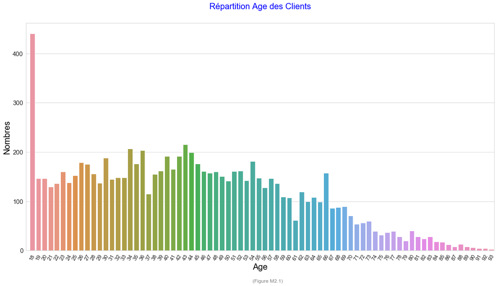

```python
df1 = cst.copy()
fig = plt.figure(figsize=(20,10))

sns.set_style("whitegrid")
ax = sns.countplot(df1['age'], orient="v")
ax.set_xlim(left=-1)
# TITRE GRAPHE
plt.title("Répartition Age des Clients", fontsize=20, color = 'Blue', y=1.05)
# Libellé Abscisse (x)
plt.xticks(rotation=60, size=13)
plt.xlabel("Age", color="black", size=20)
# Libellé Ordonnée (y)
plt.yticks(size=15)
plt.ylabel("Nombres", color='black', size=20, rotation=90)

plt.figtext(0.5,0.02,'(Figure M2.1)', fontsize=12, color = 'gray')
plt.savefig('GRAPHS/figure_M21.png', dpi=100, bbox_inches='tight')

plt.show()
plt.close()

#df1.groupby(['age']).size().reset_index(name='counts').head(5)
```

### Repartition par Tranches d'age

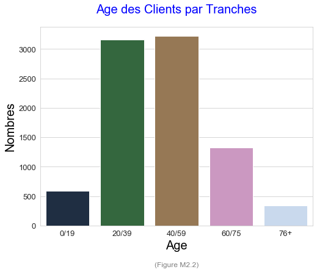

|  | tranches | counts |
| --- | --- | --- |
| 0 | 0/19 | 586 |
| 1 | 20/39 | 3155 |
| 2 | 40/59 | 3219 |
| 3 | 60/75 | 1326 |
| 4 | 76+ | 337 |

```python
df2 = cst.copy()
tranches = [0, 19, 39, 59, 75, 100]
nom_tranches = ["0/19","20/39","40/59","60/75", "76+"]
df2['tranches'] = pd.cut(df2.age, tranches, labels = nom_tranches)
df2 = df2.sort_values(['tranches', 'age'])

fig = plt.figure(figsize=(8,6))
ax = sns.countplot(df2['tranches'], palette='cubehelix')
# TITRE GRAPHE
plt.title("Age des Clients par Tranches", fontsize=20, color = 'Blue', y=1.05)
# Libellé Abscisse (x)
plt.xticks(size=13)
plt.xlabel("Age", color="black", size=20)
# Libellé Ordonnée (y)
plt.yticks(size=13)
plt.ylabel("Nombres", color='black', size=20, rotation=90)

plt.figtext(0.45,-0.03,'(Figure M2.2)', fontsize=12, color = 'gray')
plt.savefig('GRAPHS/figure_M22.png', dpi=100, bbox_inches='tight')

plt.show()
plt.close()
df2.groupby(['tranches']).size().reset_index(name='counts').head(5)
```

### Repartition par Sexe

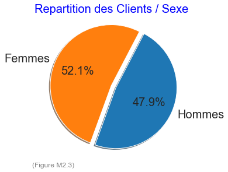

| sex | count |
| --- | --- |
| f | 4491 |
| m | 4132 |

```python
df3 = cst.groupby(['sex'])['age'].agg(["count"])
H = df3.loc['m']['count']
F = df3.loc['f']['count']

# Pie chart
vals = [H, F]
libelles = ['Hommes', 'Femmes']

fig = plt.figure(figsize=(6,4))
plt.pie(vals, labels=libelles, autopct='%0.1f%%', shadow=True, radius=1.2,
        explode=[0.1,0], startangle=-110, textprops={'fontsize': 20})
plt.title("Repartition des Clients / Sexe", fontsize=20, color = 'Blue', y=1.05)

plt.figtext(0.2,0.02,'(Figure M2.3)', fontsize=12, color = 'gray')
plt.savefig('GRAPHS/figure_M23.png', dpi=100, bbox_inches='tight')

plt.show()
plt.close()
df3.head()
```

### Les 10 plus gros Clients en terme ce CA(€) annuel

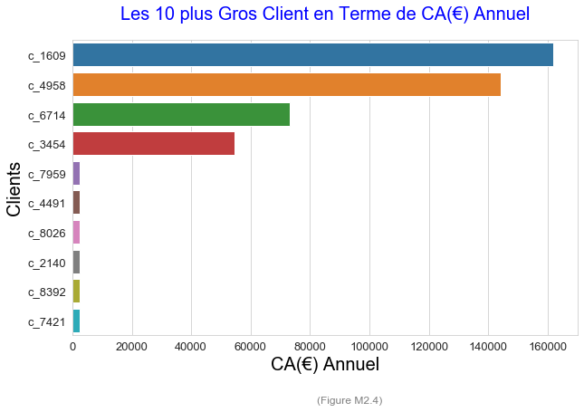

|  | client | price |
| --- | --- | --- |
| 677 | c_1609 | 162,007.34 |
| 4388 | c_4958 | 144,257.21 |
| 6337 | c_6714 | 73,197.34 |
| 2724 | c_3454 | 54,442.92 |
| 7715 | c_7959 | 2,564.25 |
| 3870 | c_4491 | 2,540.53 |
| 7791 | c_8026 | 2,537.67 |
| 1268 | c_2140 | 2,527.01 |
| 8195 | c_8392 | 2,515.98 |
| 7120 | c_7421 | 2,511.98 |

```python
df4 = sal.groupby(['client'])['price'].sum().reset_index()
df4 = df4.sort_values(['price'], ascending=False).head(10)

# TITRE GRAPHE
fig = plt.figure(figsize=(10,6))
ax = sns.barplot(x="price", y="client", orient='h', data=df4)
plt.title("Les 10 plus Gros Client en Terme de CA(€) Annuel", fontsize=20, color = 'Blue', y=1.05)
# Libellé Abscisse (x)
plt.xticks(size=13)
plt.xlabel("CA(€) Annuel", color="black", size=20)
# Libellé Ordonnée (y)
plt.yticks(size=13)
plt.ylabel("Clients", color='black', size=20, rotation=90)

plt.figtext(0.5, -0.05,'(Figure M2.4)', fontsize=12, color = 'gray')
plt.savefig('GRAPHS/figure_M24.png', dpi=100, bbox_inches='tight')

plt.show()
plt.close()
df4
```

> Nous constatons qu'il y a 4 très gros clients !!! Dont les achats sur 1an s'élèvent à plus de 50'000 €  
> Ce ne sont probablement pas des "particuliers" mais plutot des entreprises.  
> **Ils seront supprimées pour l'étude des corrélations de la mission 3.**

## Etude des Produits (basique)

- Analyse **"simple"** faite à partir des données de la table "produits" (Dataframe **"prd"**)

### Distribution des Tarifs Produits / Catégorie

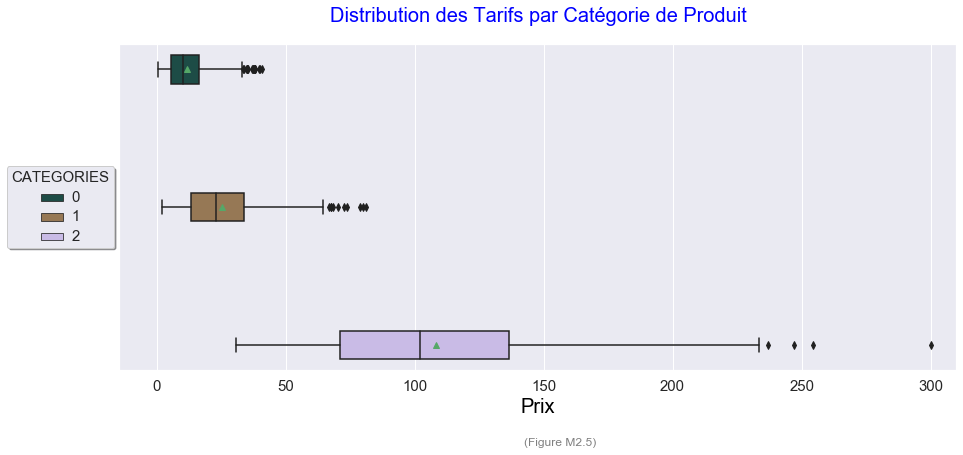

```python
df5 = prd[['categ', 'price']].copy()
df5 = df5.sort_values(['categ', 'price'])
x = df5['categ']
y = df5['price']

sns.set()
fig = plt.figure(figsize=(15,6))
ax = sns.boxplot(y, x, data=df5, orient="h", hue=x, showmeans=True, palette='cubehelix')  ## showfliers=False
ax.set_xlim(right=310)
legend = ax.legend(loc='center right', bbox_to_anchor=(0, 0.5), ncol=1, shadow=True, title='CATEGORIES')
legend.get_title().set_fontsize('15')
plt.setp(plt.gca().get_legend().get_texts(), fontsize='15') #legend 'list' fontsize

# TITRE GRAPHE
plt.title("Distribution des Tarifs par Catégorie de Produit", fontsize=20, color = 'Blue', y=1.05)
# Libellé Abscisse (x)
plt.xticks(size=15)
plt.xlabel("Prix", color='black', size=20)
# Libellé Ordonnée (y)
plt.yticks(color="white")
plt.ylabel("")

plt.figtext(0.5, -0.05,'(Figure M2.5)', fontsize=12, color = 'gray')
plt.savefig('GRAPHS/figure_M25.png', dpi=100, bbox_inches='tight')

plt.show()
plt.close()
```

> - Moyenne > Mediane : distribution asymétrique à droite, ou skewness droit

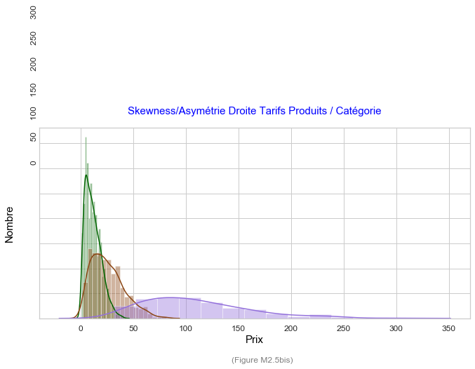

|  | categ | price | categ | price | categ | price |
| --- | --- | --- | --- | --- | --- | --- |
| count | 2,309.00 | 2,309.00 | 739.00 | 739.00 | 239.00 | 239.00 |
| mean | 0.00 | 11.73 | 1.00 | 25.53 | 2.00 | 108.35 |
| std | 0.00 | 7.56 | 0.00 | 15.43 | 0.00 | 49.56 |
| min | 0.00 | 0.62 | 1.00 | 2.00 | 2.00 | 30.99 |
| 25% | 0.00 | 5.59 | 1.00 | 13.39 | 2.00 | 71.06 |
| 50% | 0.00 | 10.32 | 1.00 | 22.99 | 2.00 | 101.99 |
| 75% | 0.00 | 16.65 | 1.00 | 33.99 | 2.00 | 136.53 |
| max | 0.00 | 40.99 | 1.00 | 80.99 | 2.00 | 300.00 |

```python
fig = plt.figure(figsize=(11,5))
sns.set_style("whitegrid")
sns.distplot(df5[df5['categ']==0]['price'] , color="darkgreen")
sns.distplot(df5[df5['categ']==1]['price'] , color="saddlebrown")
sns.distplot(df5[df5['categ']==2]['price'] , color="mediumpurple")

# TITRE GRAPHE
plt.title("Skewness/Asymétrie Droite Tarifs Produits / Catégorie", fontsize=15, color = 'Blue', y=1.05)
# Libellé Abscisse (x)
plt.xticks(size=12)
plt.xlabel("Prix", color='black', size=15)
# Libellé Ordonnée (y)
plt.ylabel("Nombre", color='black', size=15)
plt.yticks(color="white")
plt.figtext(0.11, 0.74,'0        50     100    150     200     250     300', fontsize=12, rotation=90)

plt.figtext(0.47, -0.05,'(Figure M2.5bis)', fontsize=12, color = 'gray')
plt.savefig('GRAPHS/figure_M25bis.png', dpi=100, bbox_inches='tight')

plt.show()
plt.close()

df51 = df5[df5['categ']==0].describe(include="all")
df52 = df5[df5['categ']==1].describe(include="all")
df53 = df5[df5['categ']==2].describe(include="all")
df5result = pd.concat([pd.concat([df51, df52], axis=1, join='inner'), df53], axis=1, join='inner')
df5result
```

### Les 10 produits les plus vendus (Fig.6) /// Les 10 dont le CA(€) est le plus haut (Fig.6bis)

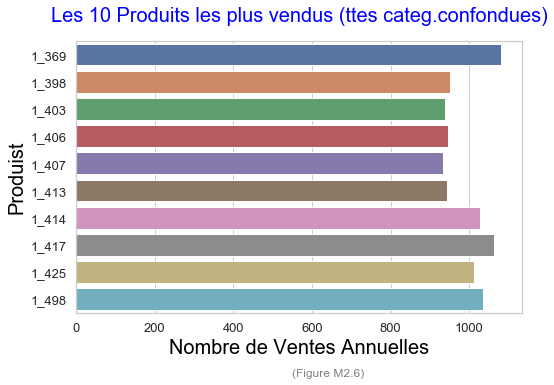

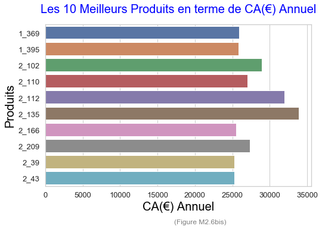

```python
# GRAPHE 1
df6nbr = sal.groupby(['prod'])['price'].size().reset_index(name='counts').sort_values(['counts'], ascending=False).head(10)

fig = plt.figure(figsize=(8,5))
ax = sns.barplot(x="counts", y="prod", orient='h', data=df6nbr)
plt.title("Les 10 Produits les plus vendus (ttes categ.confondues)", fontsize=20, color = 'Blue', y=1.05)
# Libellé Abscisse (x)
plt.xticks(size=13)
plt.xlabel("Nombre de Ventes Annuelles", color="black", size=20)
# Libellé Ordonnée (y)
plt.yticks(size=13)
plt.ylabel("Produist", color='black', size=20, rotation=90)

plt.figtext(0.5, -0.05,'(Figure M2.6)', fontsize=12, color = 'gray')
plt.savefig('GRAPHS/figure_M26.png', dpi=100, bbox_inches='tight')
plt.show()

# GRAPHE 2
df6val = sal.groupby(['prod'])['price'].sum().reset_index()
df6val = df6val.sort_values(['price'], ascending=False).head(10)

fig = plt.figure(figsize=(8,5))
ax = sns.barplot(x="price", y="prod", orient='h', data=df6val)
plt.title("Les 10 Meilleurs Produits en terme de CA(€) Annuel", fontsize=20, color = 'Blue', y=1.05)
# Libellé Abscisse (x)
plt.xticks(size=13)
plt.xlabel("CA(€) Annuel", color="black", size=20)
# Libellé Ordonnée (y)
plt.yticks(size=13)
plt.ylabel("Produits", color='black', size=20, rotation=90)

plt.figtext(0.5, -0.05,'(Figure M2.6bis)', fontsize=12, color = 'gray')
plt.savefig('GRAPHS/figure_M26bis.png', dpi=100, bbox_inches='tight')
plt.show()
plt.close()
```

## Etude des Ventes

- Analyse faite à partir des données de la table enrichi dans le notebook précédent "sales" (Dataframe **"sal"**)

### Evolution des Ventes (C.A. Mensuel) sur 1an & Nombre de Ventes de chaque Catégorie de Produits / Mois

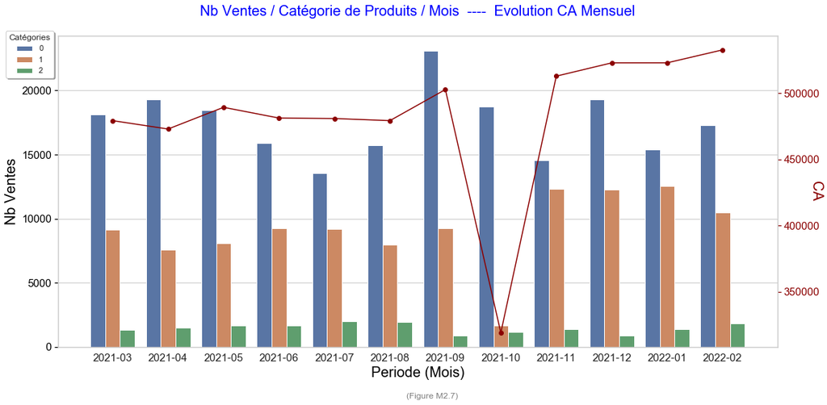

|  | period | categ | counts |
| --- | --- | --- | --- |
| 0 | 2021-03 | 0 | 18110 |
| 1 | 2021-03 | 1 | 9134 |
| 2 | 2021-03 | 2 | 1315 |
| 3 | 2021-04 | 0 | 19321 |
| 4 | 2021-04 | 1 | 7579 |

```python
fig = plt.figure(figsize=(18,8))
# TITRE GRAPHE
plt.title("Nb Ventes / Catégorie de Produits / Mois  ----  Evolution CA Mensuel", fontsize=20, color = 'Blue', y=1.05)
#plt.figtext(0.15,0.95,'Nb Ventes / Catégorie de Produits / Mois   ---   ', fontsize=25, ha='left', color = 'Black')
#plt.figtext(0.55,0.95,'Evolution CA Mensuel', fontsize=25, ha='left', color = 'darkred')

# -------------------------------------------
#  GRAPHE 1 - Nombre de Ventes (3 Barres)
# -------------------------------------------
df11 = sal.groupby(['period', 'categ']).size().reset_index(name='counts')
ax11 = sns.barplot(x="period", y="counts", hue="categ", data=df11)
ax11.legend(loc='center right', bbox_to_anchor=(0, 0.94), ncol=1, shadow=True, title="Catégories")

#df11 = pd.pivot_table(sal, values='price', index=['period'], columns=['categ'], aggfunc='count').reset_index()
#ax11 = df11.plot(x="period", rot=30, kind='bar', figsize=(18,8))   #  colormap="viridis", "inferno", "summer", "winter"

ax11.set_xlabel('Periode (Mois)', color='black', size=20)
plt.xticks(size=15)
# Make the y-axis label, ticks and tick labels match the line color.
ax11.set_ylabel('Nb Ventes', color='black', size=20)
ax11.tick_params('y', colors='black', size=5, labelsize=15)

# -------------------------------------------
#  GRAPHE 2 - Courbe Evolution CA
# -------------------------------------------
df12 = sal.groupby(['period'])['price'].agg(["sum"])
x12 = df12.index
y12 = df12['sum']

ax12 = ax11.twinx()
ax12 = sns.lineplot(x12, y12, data=df12, color='darkred')
plt.plot(x12, y12,'o', color = 'darkred')

ax12.set_ylabel('CA', color='darkred', size=20, rotation=-90)
ax12.tick_params('y', colors='darkred', size=5, labelsize=15)
ax12.grid(False)

plt.figtext(0.5, 0,'(Figure M2.7)', fontsize=12, color = 'gray')
plt.savefig('GRAPHS/figure_M27.png', dpi=100, bbox_inches='tight')

plt.show()
plt.close()
df11.head()
```

### Même etude avec Reference 0_2245 prise en compte

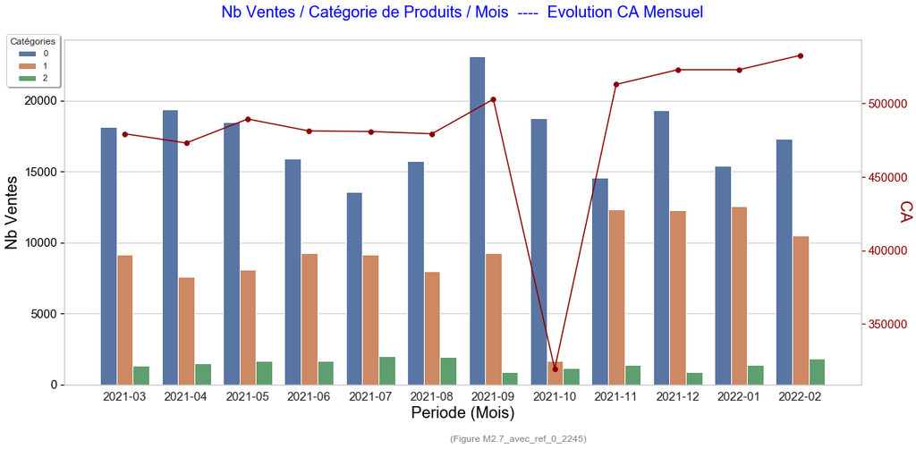

|  | period | categ | counts |
| --- | --- | --- | --- |
| 0 | 2021-03 | 0 | 18119 |
| 1 | 2021-03 | 1 | 9134 |
| 2 | 2021-03 | 2 | 1315 |
| 3 | 2021-04 | 0 | 19335 |
| 4 | 2021-04 | 1 | 7579 |

```python
fig = plt.figure(figsize=(18,8))
# TITRE GRAPHE
plt.title("Nb Ventes / Catégorie de Produits / Mois  ----  Evolution CA Mensuel", fontsize=20, color = 'Blue', y=1.05)
# -------------------------------------------
#  GRAPHE 1 - Nombre de Ventes (3 Barres)
# -------------------------------------------
df11 = sal_ref.groupby(['period', 'categ']).size().reset_index(name='counts')
ax11 = sns.barplot(x="period", y="counts", hue="categ", data=df11)
ax11.legend(loc='center right', bbox_to_anchor=(0, 0.94), ncol=1, shadow=True, title="Catégories")

ax11.set_xlabel('Periode (Mois)', color='black', size=20)
plt.xticks(size=15)
# Make the y-axis label, ticks and tick labels match the line color.
ax11.set_ylabel('Nb Ventes', color='black', size=20)
ax11.tick_params('y', colors='black', size=5, labelsize=15)

# -------------------------------------------
#  GRAPHE 2 - Courbe Evolution CA
# -------------------------------------------
df12 = sal_ref.groupby(['period'])['price'].agg(["sum"])
x12 = df12.index
y12 = df12['sum']

ax12 = ax11.twinx()
ax12 = sns.lineplot(x12, y12, data=df12, color='darkred')
plt.plot(x12, y12,'o', color = 'darkred')

ax12.set_ylabel('CA', color='darkred', size=20, rotation=-90)
ax12.tick_params('y', colors='darkred', size=5, labelsize=15)
ax12.grid(False)

plt.figtext(0.5, 0,'(Figure M2.7_avec_ref_0_2245)', fontsize=12, color = 'gray')
plt.savefig('GRAPHS/figure_M27_avec_ref_0_2245.png', dpi=100, bbox_inches='tight')

plt.show()
plt.close()
df11.head()
```

#### TOTAL Annuel Nb Ventes / Catégorie

```python
df11tot = df11.groupby(['categ'])['counts'].sum().reset_index()
df11tot
```

|  | categ | counts |
| --- | --- | --- |
| 0 | 0 | 209529 |
| 1 | 1 | 109735 |
| 2 | 2 | 17552 |

### CA Mensuels par Categorie (Scatterplots)

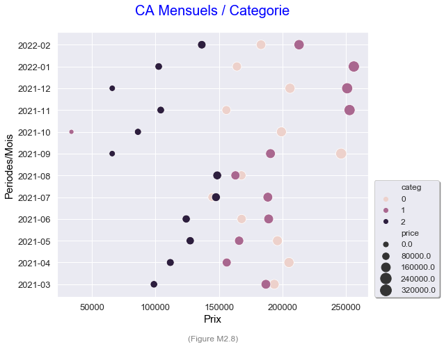

|  | period | categ | price |
| --- | --- | --- | --- |
| 0 | 2021-03 | 0 | 193,566.38 |
| 1 | 2021-03 | 1 | 186,974.17 |
| 2 | 2021-03 | 2 | 98,771.48 |
| 3 | 2021-04 | 0 | 205,159.67 |
| 4 | 2021-04 | 1 | 156,138.35 |

```python
df81 = sal.groupby(['period', 'categ'])['price'].sum().reset_index()
sns.set()
plt.figure(figsize=(8,7))
ax = sns.scatterplot(x="price",y="period",hue='categ', size="price", sizes=(50, 250), data=df81)
ax.legend(loc=(1.02,0), fontsize=12, shadow=True)

# TITRE GRAPHE
plt.title("CA Mensuels / Categorie", fontsize=20, color = 'Blue', y=1.05)
# Libellé Abscisse (x)
plt.xlabel("Prix", color='black', size=15)
plt.xticks(size=13)
# Libellé Ordonnée (y)
plt.ylabel("Periodes/Mois", color="black", size=15, rotation=90)
plt.yticks(size=13)

plt.figtext(0.45, 0,'(Figure M2.8)', fontsize=12, color = 'gray')
plt.savefig('GRAPHS/figure_M28.png', dpi=100, bbox_inches='tight')

plt.show()
plt.close()
df81.head()
```

### Même etude avec Reference 0_2245 prise en compte

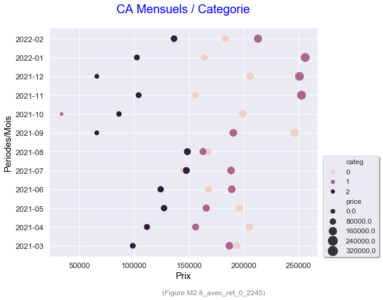

|  | period | categ | price |
| --- | --- | --- | --- |
| 0 | 2021-03 | 0 | 193,659.26 |
| 1 | 2021-03 | 1 | 186,974.17 |
| 2 | 2021-03 | 2 | 98,771.48 |
| 3 | 2021-04 | 0 | 205,304.15 |
| 4 | 2021-04 | 1 | 156,138.35 |

```python
df82 = sal_ref.groupby(['period', 'categ'])['price'].sum().reset_index()
sns.set()
plt.figure(figsize=(8,7))
ax = sns.scatterplot(x="price",y="period",hue='categ', size="price", sizes=(50, 250), data=df82)
ax.legend(loc=(1.02,0), fontsize=12, shadow=True)

# TITRE GRAPHE
plt.title("CA Mensuels / Categorie", fontsize=20, color = 'Blue', y=1.05)
# Libellé Abscisse (x)
plt.xlabel("Prix", color='black', size=15)
plt.xticks(size=13)
# Libellé Ordonnée (y)
plt.ylabel("Periodes/Mois", color="black", size=15, rotation=90)
plt.yticks(size=13)

plt.figtext(0.45, 0,'(Figure M2.8_avec_ref_0_2245)', fontsize=12, color = 'gray')
plt.savefig('GRAPHS/figure_M28_avec_ref_0_2245.png', dpi=100, bbox_inches='tight')

plt.show()
plt.close()
df82.head()
```

#### TOTAL CA(€) Annuel / Catégorie

```python
df81tot = df81.groupby(['categ'])['price'].sum().reset_index()
df81tot
```

|  | categ | price |
| --- | --- | --- |
| 0 | 0 | 2,229,722.65 |
| 1 | 1 | 2,247,384.41 |
| 2 | 2 | 1,319,470.71 |

```python
df82tot = df82.groupby(['categ'])['price'].sum().reset_index()
df82tot
```

|  | categ | price |
| --- | --- | --- |
| 0 | 0 | 2,230,785.61 |
| 1 | 1 | 2,247,384.41 |
| 2 | 2 | 1,319,470.71 |

### Ventes par Tranches horaire

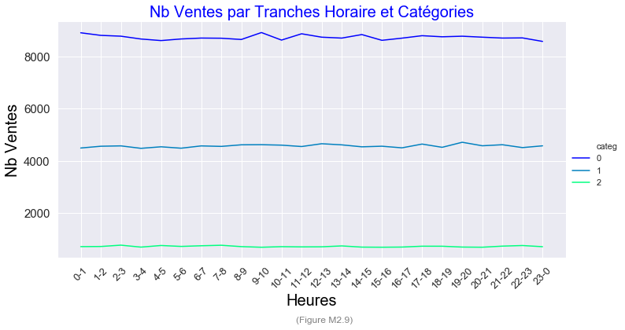

```python
df9 = sal[['categ', 'time', 'prod', 'price']].copy()
heure = df9['time'].str[0:2:1].astype('int')
minute = df9['time'].str[3:5:1].astype('int')/60
df9['hm'] = heure + minute

tranches = [-1,1,2,3,4,5,6,7,8,9,10,11,12,13,14,15,16,17,18,19,20,21,22,23,24]
nom_tranches = ["0-1","1-2","2-3","3-4", "4-5", "5-6", "6-7", "7-8", "8-9", "9-10", "10-11", "11-12", "12-13",
                "13-14", "14-15", "15-16", "16-17", "17-18", "18-19", "19-20", "20-21", "21-22", "22-23", "23-0"]
df9['tranches'] = pd.cut(df9.hm, tranches, labels = nom_tranches)
df9 = df9.groupby(['tranches', 'categ'])['prod'].size().reset_index(name='counts')
df9 = df9.sort_values(['tranches'])

sns.set()
ax = sns.relplot(x="tranches", y="counts", height=5, hue="categ", palette="winter", kind="line", aspect=2.0, data=df9)
# TITRE GRAPHE
plt.title("Nb Ventes par Tranches Horaire et Catégories", fontsize=20, color = 'Blue', y=1.05)
# Libellé Abscisse (x)
plt.xticks(rotation=45, size=13)
plt.xlabel("Heures", color="black", size=20)
# Libellé Ordonnée (y)
plt.yticks(size=15)
plt.ylabel("Nb Ventes", color='black', size=20, rotation=90)

plt.figtext(0.47, -0.1,'(Figure M2.9)', fontsize=12, color = 'gray')
plt.savefig('GRAPHS/figure_M29.png', dpi=100, bbox_inches='tight')

plt.show()
plt.close()
```

#### Nb Ventes Moyenne / Heure

```python
df9mh = df9.groupby(['categ'])['counts'].mean().reset_index()
df9mh['moyh'] = df9mh['counts'] / 365
df9mh.head()
```

|  | categ | counts | moyh |
| --- | --- | --- | --- |
| 0 | 0 | 8,726.08 | 23.91 |
| 1 | 1 | 4,572.29 | 12.53 |
| 2 | 2 | 731.33 | 2.00 |

## Courbe de Lorenz / Indice de Gini

Fondements de l'analyse :

### Analyse des Prix de Ventes sur l'année

```python
sal.head()
```

|  | session_id | client | sex | age | birthyear | prod | price | categ | period | year | month | day | time | session_date |
| --- | --- | --- | --- | --- | --- | --- | --- | --- | --- | --- | --- | --- | --- | --- |
| 0 | s_18746 | c_4450 | f | 45 | 1977 | 0_1483 | 4.99 | 0 | 2021-04 | 2021 | 4 | 10 | 18:37 | 2021-04-10 18:37:28.723910 |
| 1 | s_140787 | c_5433 | f | 41 | 1981 | 0_1483 | 4.99 | 0 | 2021-12 | 2021 | 12 | 27 | 11:11 | 2021-12-27 11:11:12.123067 |
| 2 | s_110736 | c_857 | m | 37 | 1985 | 0_1483 | 4.99 | 0 | 2021-10 | 2021 | 10 | 27 | 04:56 | 2021-10-27 04:56:38.293970 |
| 3 | s_57626 | c_3679 | f | 33 | 1989 | 0_1483 | 4.99 | 0 | 2021-07 | 2021 | 7 | 4 | 06:43 | 2021-07-04 06:43:45.676567 |
| 4 | s_92165 | c_1609 | m | 42 | 1980 | 0_1483 | 4.99 | 0 | 2021-09 | 2021 | 9 | 19 | 08:45 | 2021-09-19 08:45:43.735331 |

- Chargement des valeurs "price" du datafrane des ventes dans une variable et on la **"TRIE"** par ordre croissant !!!

```python
df10 = sal[['price']].copy()
ventes = df10.sort_values(['price'], ascending=[True])
```

#### Détermination de la courbe de **Lorenz**

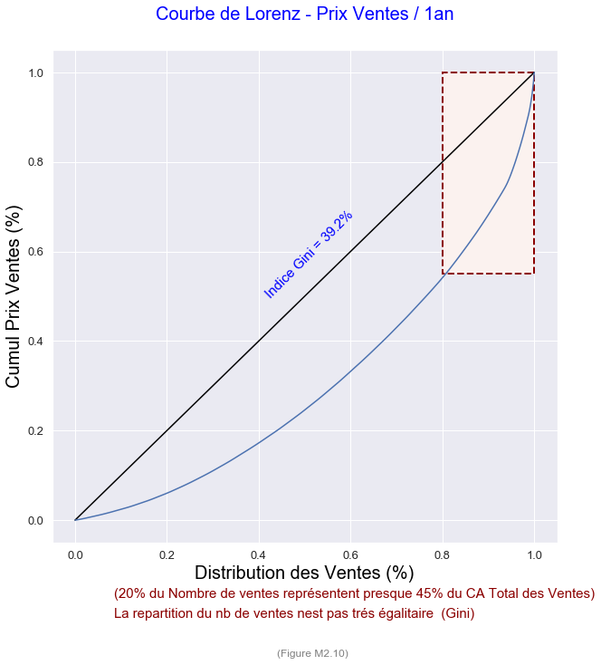

```python
# lorenz = np.cumsum(np.sort(priceachats.head()
lorenz = np.cumsum(ventes) / ventes.sum()
lorenz = np.append([0],lorenz) # La courbe de Lorenz commence à 0

fig, ax = plt.subplots(figsize=[10,10])
# TITRE GRAPHE
plt.title("Courbe de Lorenz - Prix Ventes / 1an", fontsize=20, color = 'Blue', y=1.05)
# Libellé Abscisse (x)
plt.xticks(size=13)
plt.xlabel("Distribution des Ventes (%)", color="black", size=20)
# Libellé Ordonnée (y)
plt.yticks(size=13)
plt.ylabel("Cumul Prix Ventes (%)", color='black', size=20, rotation=90)

## Ligne d'égalité
ax.plot([0,1], [0,1], color='black')
## Courbe de Lorenz
plt.plot(np.linspace(0,1,len(lorenz)),lorenz,drawstyle='steps-post')

# TRACE D'UN RECTANGLE pour Analyse
rect = plt.Rectangle((1, 1), -0.2, -0.45, edgecolor = 'darkred', facecolor = '#FBF2EF',
                      fill = True, linestyle = 'dashed', linewidth = 2, zorder = 1)     #  hatch = '/',
ax.add_artist(rect)
# Analyses
plt.figtext(0.45,0.5,'Indice Gini = 39.2%', fontsize=15, color = 'blue', rotation = 45)
plt.figtext(0.22,0.04,'(20% du Nombre de ventes représentent presque 45% du CA Total des Ventes)', fontsize=15, color = 'darkred')
plt.figtext(0.22,0.01,'La repartition du nb de ventes n''est pas trés égalitaire  (Gini)', fontsize=15, color = 'darkred')

plt.figtext(0.47, -0.05,'(Figure M2.10)', fontsize=12, color = 'gray')
plt.savefig('GRAPHS/figure_M210(lorenz).png', dpi=100, bbox_inches='tight')

plt.show()
plt.close()
```

#### Calcul du coefficient de **Gini**.

- Calcul de l'aire sous courbe = aire_ss_courbe (La dernière valeur ne participe pas à l'aire, d'où "[:-1]")
- Calcul de la Surface (S) entre aire de la 1ere bissectrice et la courbe de Lorenz
- Coeff.Gini = 2 * S

```python
aire_ss_courbe = lorenz[:-1].sum()/len(lorenz)
S = 0.5 - aire_ss_courbe
# Gini
gini = round(2*S, 3)
Markdown('{}<strong>{}'.format("Coefficient de Gini : ", gini))
```

Coefficient de Gini : **0.392**

```python
dureetotale = round(time.time() - trt_start_time, 5)
print("--- Durée TOTALE du Notebook PJ4 Mission 2 --- ", "%s seconds" % dureetotale)
```

```
--- Durée TOTALE du Notebook PJ4 Mission 2 ---  9.58634 seconds
```